# Project 1

Kenneth Fleming

11/25/2016

Read in the data (assuming the activity.csv file is in the current working directory) and summarize the data.

```r
activity <- read.csv("activity.csv")
summary(activity)
```

```
##      steps              date          interval
##  Min.   :  0.00   10/1/12 :  288   Min.   :   0.0
##  1st Qu.:  0.00   10/10/12:  288   1st Qu.: 588.8
##  Median :  0.00   10/11/12:  288   Median :1177.5
##  Mean   : 37.38   10/12/12:  288   Mean   :1177.5
##  3rd Qu.: 12.00   10/13/12:  288   3rd Qu.:1766.2
##  Max.   :806.00   10/14/12:  288   Max.   :2355.0
##  NA's   :2304     (Other) :15840
```

Transform the ‘date’ column into a date field. We won’t show the results since the date transformation is very long.

```r
activity$date <- as.Date(activity$date, "%m/%d/%y")
```

Aggregate the steps for each day and create a histogram showing the frequency of various step totals

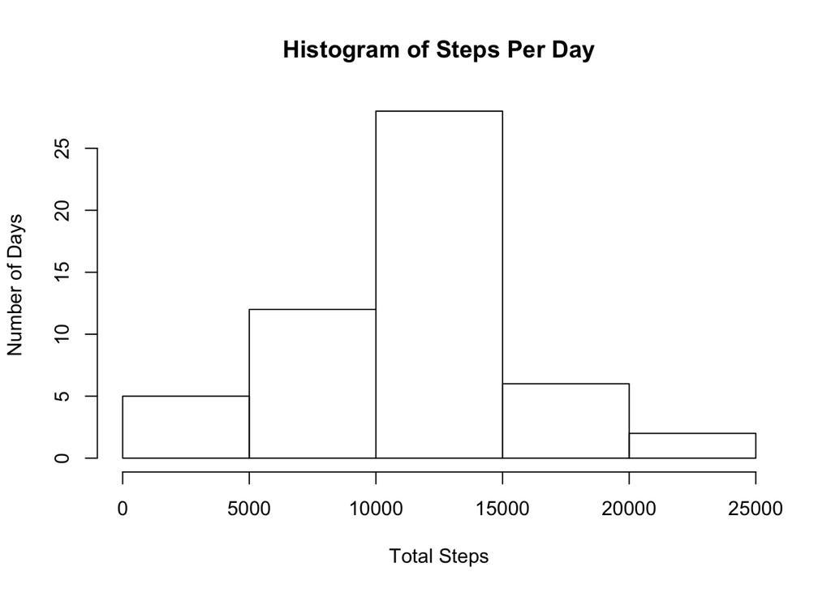

```r
stepsperday <- aggregate(steps ~ date, data=activity, sum)
hist(stepsperday$steps, main = "Histogram of Steps Per Day", xlab = "Total Steps", ylab = "Number of Days")
```

Calculate the mean and median.

```r
mean(stepsperday$steps)
```

```
## [1] 10766.19
```

```r
median(stepsperday$steps)
```

```
## [1] 10765
```

Make a time series plot of the 5-minute interval (x-axis) and the average number of steps taken, averaged across all days (y-axis)

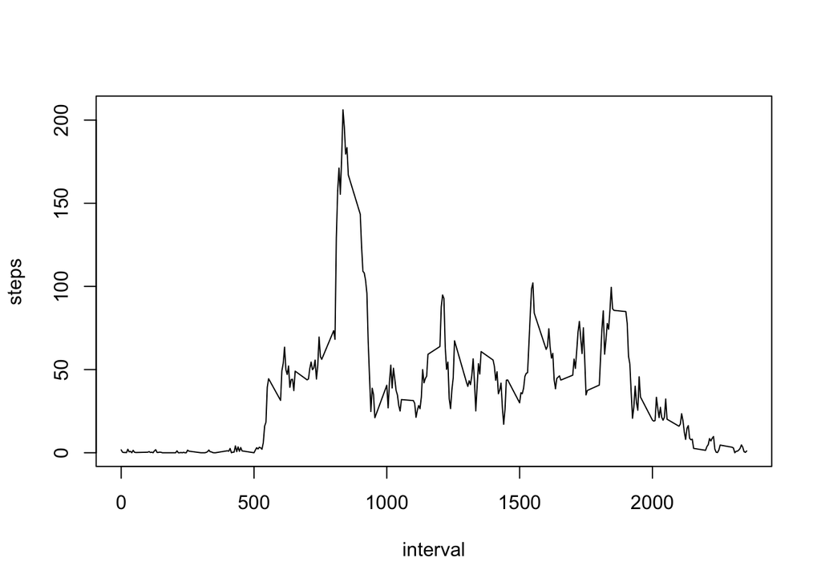

```r
intervaldata <- aggregate(steps ~ interval, data=activity, mean)
plot(intervaldata, type = "l")
```

Which 5-minute interval, on average across all the days in the dataset, contains the maximum number of steps?

```r
largest <- which.max(intervaldata$steps)
max <- intervaldata[largest,]
max$interval
```

```
## [1] 835
```

Calculate and report the total number of missing values in the dataset.

```r
 sum(is.na(activity))
```

```
## [1] 2304
```

Devise a strategy for filling in all of the missing values in the dataset. Create a new dataset that is equal to the original dataset but with the missing data filled in.

The code creates a new data set then loops through the data and replaces any ‘NA’ values with the mean of the interval in which the ‘NA’ is found.

```r
activity2 <- activity
for (i in which(sapply(activity2, is.numeric))) {
    for (j in which(is.na(activity2[, i]))) {
        activity2[j, i] <- mean(activity2[activity2[, "interval"] == activity2[j, "interval"], i],  na.rm = TRUE)
    }
}
```

Aggregate the steps for each day and create a histogram showing the frequency of various step totals. Make a histogram of the total number of steps taken each day and calculate and report the mean and median total number of steps taken per day.

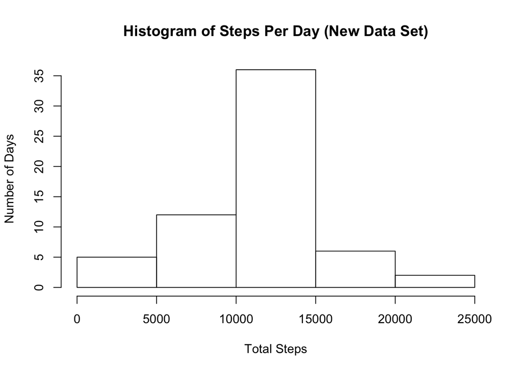

```r
stepsperday <- aggregate(steps ~ date, data=activity2, sum)
hist(stepsperday$steps, main = "Histogram of Steps Per Day (New Data Set)", xlab = "Total Steps", ylab = "Number of Days")
```

Calculate the mean and median.

```r
mean(stepsperday$steps)
```

```
## [1] 10766.19
```

```r
median(stepsperday$steps)
```

```
## [1] 10766.19
```

Create a new factor variable in the dataset with two levels weekday and weekend indicating whether a given date is a weekday or weekend day.

```r
activity2$weekday <- weekdays(activity2$date)
activity2$weekday2 <- ifelse(activity2$weekday != "Saturday" & activity2$weekday != "Sunday", c("Weekday"), c("Weekend"))
weekday <- subset(activity2, weekday2 == "Weekday")
weekend <- subset(activity2, weekday2 == "Weekend")
```

Make a panel plot containing a time series plot of the 5-minute interval (x-axis) and the average number of steps taken, averaged across all weekday days or weekend days (y-axis).

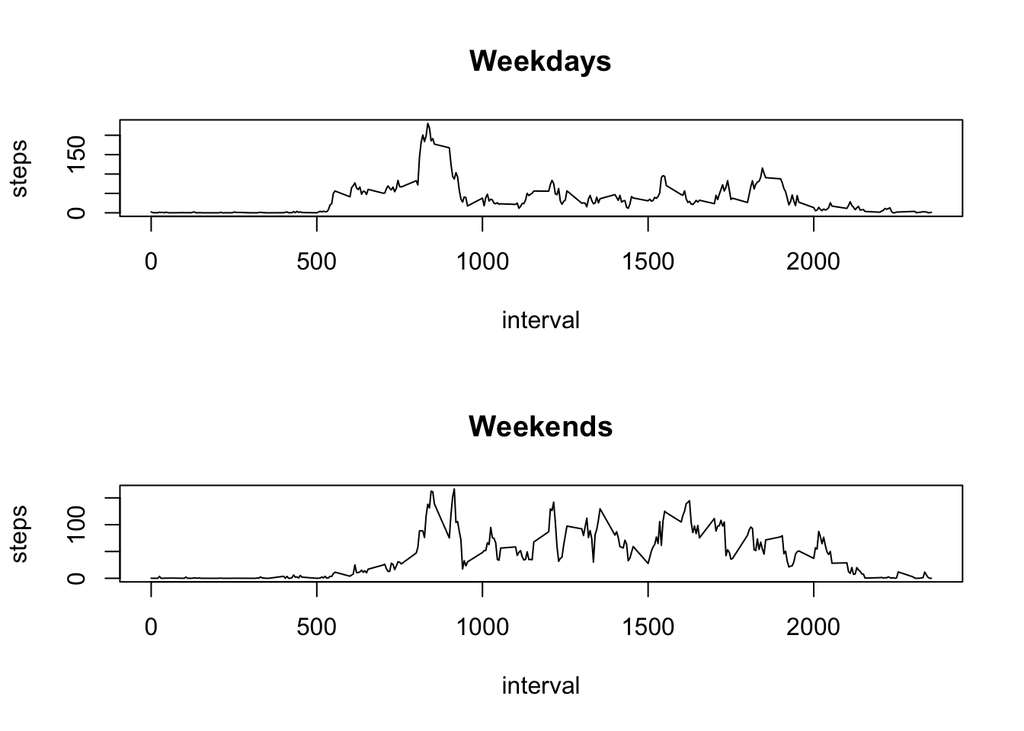

```r
intervalweekday <- aggregate(steps ~ interval, data=weekday, mean)
intervalweekend <- aggregate(steps ~ interval, data=weekend, mean)
par(mfrow=c(2,1))
plot(intervalweekday, type = "l", main = "Weekdays")
plot(intervalweekend, type = "l", main = "Weekends")
```